# IMPORTING EXCEL DATA

Excel is a widely used data analysis tool. There are already a lot of packages interacting with Excel to deal with the data in R.

### 2.1 readxl

For most data related tasks, Excel file contains different sheets that contain tabular data. For example, this *cities.xlsx* contains two sheets containing data of total population of some capitals for two different years.

[figure not shown]

When you work in R, you typically want to explore your excel file first and then import some data from it. The **readxl** package developed by Hadley Wickham makes it easy to get data out of Excel and into R.

```r
library(readxl)
```

**readxl** basically contains two main functions:

- `excel_sheet`: lists the different sheets in the Excel file.
- `read_excel`: imports the sheet data into R.

**readxl** can handle both *.xls* as *.xlsx* files. Before you can start importing from Excel, you should find out which sheets are available in the workbook.

```r
excel_sheets("urbanpop.xlsx")
```

```
## [1] "1960-1966" "1967-1974" "1975-2011"
```

This dataset contains urban population metrics for practically all countries in the world throughout time (Source: [Gapminder](https://www.gapminder.org/)). It contains three sheets for three different time periods. In each sheet, the first row contains the column names. We already know the sheet names now, but that’s just the names, not the actual population data. `read_excel` imports the sheet data into R. By default the first sheet in the Excel file is imported as a tibble.

```r
read_excel("urbanpop.xlsx")
```

```
## # A tibble: 209 x 8
##    country           `1960`   `1961`   `1962`   `1963`   `1964`   `1965`  `1966`
##    <chr>              <dbl>    <dbl>    <dbl>    <dbl>    <dbl>    <dbl>   <dbl>
##  1 Afghanistan       769308   8.15e5   8.59e5   9.04e5   9.51e5   1.00e6  1.06e6
##  2 Albania           494443   5.12e5   5.29e5   5.47e5   5.66e5   5.84e5  6.03e5
##  3 Algeria          3293999   3.52e6   3.74e6   3.97e6   4.22e6   4.49e6  4.65e6
##  4 American Samoa        NA   1.37e4   1.42e4   1.48e4   1.54e4   1.60e4  1.67e4
##  5 Andorra               NA   8.72e3   9.70e3   1.07e4   1.19e4   1.31e4  1.42e4
##  6 Angola            521205   5.48e5   5.80e5   6.12e5   6.45e5   6.79e5  7.18e5
##  7 Antigua and Ba~    21699   2.16e4   2.17e4   2.17e4   2.18e4   2.19e4  2.20e4
##  8 Argentina       15224096   1.55e7   1.59e7   1.63e7   1.67e7   1.70e7  1.74e7
##  9 Armenia           957974   1.01e6   1.06e6   1.12e6   1.17e6   1.23e6  1.28e6
## 10 Aruba              24996   2.81e4   2.85e4   2.88e4   2.89e4   2.91e4  2.93e4
## # ... with 199 more rows
```

Explicitly tell read_excel() which sheet to import:

```r
read_excel("urbanpop.xlsx", sheet = 3)
```

```
## # A tibble: 209 x 38
##    country `1975` `1976` `1977` `1978` `1979` `1980` `1981` `1982` `1983` `1984`
##    <chr>    <dbl>  <dbl>  <dbl>  <dbl>  <dbl>  <dbl>  <dbl>  <dbl>  <dbl>  <dbl>
##  1 Afghan~ 1.79e6 1.91e6 2.02e6 2.14e6 2.27e6 2.40e6 2.49e6 2.59e6 2.69e6 2.80e6
##  2 Albania 7.85e5 8.08e5 8.31e5 8.54e5 8.78e5 9.02e5 9.27e5 9.52e5 9.78e5 1.01e6
##  3 Algeria 6.46e6 6.77e6 7.10e6 7.45e6 7.81e6 8.19e6 8.64e6 9.11e6 9.59e6 1.01e7
##  4 Americ~ 2.16e4 2.20e4 2.25e4 2.29e4 2.35e4 2.42e4 2.52e4 2.63e4 2.77e4 2.91e4
##  5 Andorra 2.70e4 2.84e4 2.97e4 3.10e4 3.26e4 3.44e4 3.64e4 3.86e4 4.10e4 4.32e4
##  6 Angola  1.27e6 1.37e6 1.48e6 1.60e6 1.72e6 1.86e6 2.02e6 2.19e6 2.37e6 2.56e6
##  7 Antigu~ 2.38e4 2.40e4 2.42e4 2.43e4 2.44e4 2.43e4 2.42e4 2.39e4 2.36e4 2.33e4
##  8 Argent~ 2.11e7 2.16e7 2.20e7 2.24e7 2.29e7 2.33e7 2.38e7 2.43e7 2.48e7 2.53e7
##  9 Armenia 1.80e6 1.85e6 1.90e6 1.95e6 2.00e6 2.05e6 2.08e6 2.12e6 2.16e6 2.20e6
## 10 Aruba   3.07e4 3.06e4 3.05e4 3.04e4 3.03e4 3.03e4 3.06e4 3.09e4 3.14e4 3.17e4
## # ... with 199 more rows, and 27 more variables: `1985` <dbl>, `1986` <dbl>,
## #   `1987` <dbl>, `1988` <dbl>, `1989` <dbl>, `1990` <dbl>, `1991` <dbl>,
## #   `1992` <dbl>, `1993` <dbl>, `1994` <dbl>, `1995` <dbl>, `1996` <dbl>,
## #   `1997` <dbl>, `1998` <dbl>, `1999` <dbl>, `2000` <dbl>, `2001` <dbl>,
## #   `2002` <dbl>, `2003` <dbl>, `2004` <dbl>, `2005` <dbl>, `2006` <dbl>,
## #   `2007` <dbl>, `2008` <dbl>, `2009` <dbl>, `2010` <dbl>, `2011` <dbl>
```

The `sheet` argument works both with index or the sheet name.

```r
read_excel("urbanpop.xlsx", sheet = "1975-2011")
```

```
## # A tibble: 209 x 38
##    country `1975` `1976` `1977` `1978` `1979` `1980` `1981` `1982` `1983` `1984`
##    <chr>    <dbl>  <dbl>  <dbl>  <dbl>  <dbl>  <dbl>  <dbl>  <dbl>  <dbl>  <dbl>
##  1 Afghan~ 1.79e6 1.91e6 2.02e6 2.14e6 2.27e6 2.40e6 2.49e6 2.59e6 2.69e6 2.80e6
##  2 Albania 7.85e5 8.08e5 8.31e5 8.54e5 8.78e5 9.02e5 9.27e5 9.52e5 9.78e5 1.01e6
##  3 Algeria 6.46e6 6.77e6 7.10e6 7.45e6 7.81e6 8.19e6 8.64e6 9.11e6 9.59e6 1.01e7
##  4 Americ~ 2.16e4 2.20e4 2.25e4 2.29e4 2.35e4 2.42e4 2.52e4 2.63e4 2.77e4 2.91e4
##  5 Andorra 2.70e4 2.84e4 2.97e4 3.10e4 3.26e4 3.44e4 3.64e4 3.86e4 4.10e4 4.32e4
##  6 Angola  1.27e6 1.37e6 1.48e6 1.60e6 1.72e6 1.86e6 2.02e6 2.19e6 2.37e6 2.56e6
##  7 Antigu~ 2.38e4 2.40e4 2.42e4 2.43e4 2.44e4 2.43e4 2.42e4 2.39e4 2.36e4 2.33e4
##  8 Argent~ 2.11e7 2.16e7 2.20e7 2.24e7 2.29e7 2.33e7 2.38e7 2.43e7 2.48e7 2.53e7
##  9 Armenia 1.80e6 1.85e6 1.90e6 1.95e6 2.00e6 2.05e6 2.08e6 2.12e6 2.16e6 2.20e6
## 10 Aruba   3.07e4 3.06e4 3.05e4 3.04e4 3.03e4 3.03e4 3.06e4 3.09e4 3.14e4 3.17e4
## # ... with 199 more rows, and 27 more variables: `1985` <dbl>, `1986` <dbl>,
## #   `1987` <dbl>, `1988` <dbl>, `1989` <dbl>, `1990` <dbl>, `1991` <dbl>,
## #   `1992` <dbl>, `1993` <dbl>, `1994` <dbl>, `1995` <dbl>, `1996` <dbl>,
## #   `1997` <dbl>, `1998` <dbl>, `1999` <dbl>, `2000` <dbl>, `2001` <dbl>,
## #   `2002` <dbl>, `2003` <dbl>, `2004` <dbl>, `2005` <dbl>, `2006` <dbl>,
## #   `2007` <dbl>, `2008` <dbl>, `2009` <dbl>, `2010` <dbl>, `2011` <dbl>
```

However, loading in every sheet manually and then merging them in a list can be quite tedious. Automate this with `lapply()`:

```r
pop_list <- lapply(excel_sheets("urbanpop.xlsx"),
                   read_excel,
                   path = "urbanpop.xlsx")
```

Display the structure of `pop_list`:

```r
str(pop_list)
```

```
## List of 3
##  $ : tibble [209 x 8] (S3: tbl_df/tbl/data.frame)
##   ..$ country: chr [1:209] "Afghanistan" "Albania" "Algeria" "American Samoa" ...
##   ..$ 1960   : num [1:209] 769308 494443 3293999 NA NA ...
##   ..$ 1961   : num [1:209] 814923 511803 3515148 13660 8724 ...
##   ..$ 1962   : num [1:209] 858522 529439 3739963 14166 9700 ...
##   ..$ 1963   : num [1:209] 903914 547377 3973289 14759 10748 ...
##   ..$ 1964   : num [1:209] 951226 565572 4220987 15396 11866 ...
##   ..$ 1965   : num [1:209] 1000582 583983 4488176 16045 13053 ...
##   ..$ 1966   : num [1:209] 1058743 602512 4649105 16693 14217 ...
##  $ : tibble [209 x 9] (S3: tbl_df/tbl/data.frame)
##   ..$ country: chr [1:209] "Afghanistan" "Albania" "Algeria" "American Samoa" ...
##   ..$ 1967   : num [1:209] 1119067 621180 4826104 17349 15440 ...
##   ..$ 1968   : num [1:209] 1182159 639964 5017299 17996 16727 ...
##   ..$ 1969   : num [1:209] 1248901 658853 5219332 18619 18088 ...
##   ..$ 1970   : num [1:209] 1319849 677839 5429743 19206 19529 ...
##   ..$ 1971   : num [1:209] 1409001 698932 5619042 19752 20929 ...
##   ..$ 1972   : num [1:209] 1502402 720207 5815734 20263 22406 ...
##   ..$ 1973   : num [1:209] 1598835 741681 6020647 20742 23937 ...
##   ..$ 1974   : num [1:209] 1696445 763385 6235114 21194 25482 ...
##  $ : tibble [209 x 38] (S3: tbl_df/tbl/data.frame)
##   ..$ country: chr [1:209] "Afghanistan" "Albania" "Algeria" "American Samoa" ...
##   ..$ 1975   : num [1:209] 1793266 785350 6460138 21632 27019 ...
##   ..$ 1976   : num [1:209] 1905033 807990 6774099 22047 28366 ...
##   ..$ 1977   : num [1:209] 2021308 830959 7102902 22452 29677 ...
##   ..$ 1978   : num [1:209] 2142248 854262 7447728 22899 31037 ...
##   ..$ 1979   : num [1:209] 2268015 877898 7810073 23457 32572 ...
##   ..$ 1980   : num [1:209] 2398775 901884 8190772 24177 34366 ...
##   ..$ 1981   : num [1:209] 2493265 927224 8637724 25173 36356 ...
##   ..$ 1982   : num [1:209] 2590846 952447 9105820 26342 38618 ...
##   ..$ 1983   : num [1:209] 2691612 978476 9591900 27655 40983 ...
##   ..$ 1984   : num [1:209] 2795656 1006613 10091289 29062 43207 ...
##   ..$ 1985   : num [1:209] 2903078 1037541 10600112 30524 45119 ...
##   ..$ 1986   : num [1:209] 3006983 1072365 11101757 32014 46254 ...
##   ..$ 1987   : num [1:209] 3113957 1109954 11609104 33548 47019 ...
##   ..$ 1988   : num [1:209] 3224082 1146633 12122941 35095 47669 ...
##   ..$ 1989   : num [1:209] 3337444 1177286 12645263 36618 48577 ...
##   ..$ 1990   : num [1:209] 3454129 1198293 13177079 38088 49982 ...
##   ..$ 1991   : num [1:209] 3617842 1215445 13708813 39600 51972 ...
##   ..$ 1992   : num [1:209] 3788685 1222544 14248297 41049 54469 ...
##   ..$ 1993   : num [1:209] 3966956 1222812 14789176 42443 57079 ...
##   ..$ 1994   : num [1:209] 4152960 1221364 15322651 43798 59243 ...
##   ..$ 1995   : num [1:209] 4347018 1222234 15842442 45129 60598 ...
##   ..$ 1996   : num [1:209] 4531285 1228760 16395553 46343 60927 ...
##   ..$ 1997   : num [1:209] 4722603 1238090 16935451 47527 60462 ...
##   ..$ 1998   : num [1:209] 4921227 1250366 17469200 48705 59685 ...
##   ..$ 1999   : num [1:209] 5127421 1265195 18007937 49906 59281 ...
##   ..$ 2000   : num [1:209] 5341456 1282223 18560597 51151 59719 ...
##   ..$ 2001   : num [1:209] 5564492 1315690 19198872 52341 61062 ...
##   ..$ 2002   : num [1:209] 5795940 1352278 19854835 53583 63212 ...
##   ..$ 2003   : num [1:209] 6036100 1391143 20529356 54864 65802 ...
##   ..$ 2004   : num [1:209] 6285281 1430918 21222198 56166 68301 ...
##   ..$ 2005   : num [1:209] 6543804 1470488 21932978 57474 70329 ...
##   ..$ 2006   : num [1:209] 6812538 1512255 22625052 58679 71726 ...
##   ..$ 2007   : num [1:209] 7091245 1553491 23335543 59894 72684 ...
##   ..$ 2008   : num [1:209] 7380272 1594351 24061749 61118 73335 ...
##   ..$ 2009   : num [1:209] 7679982 1635262 24799591 62357 73897 ...
##   ..$ 2010   : num [1:209] 7990746 1676545 25545622 63616 74525 ...
##   ..$ 2011   : num [1:209] 8316976 1716842 26216968 64817 75207 ...
```

Next to the `path` and `sheet` arguments, there are also other arguments that you can specify in `read_excel()`.

- `col_names`: by default is TRUE, denoting whether the first row in the Excel sheets contains the column names. If this is not the case, you can set `col_names` to `FALSE`. In this case, R will choose column names for you. You can also choose to set `col_names` to a character vector with names for each column. Import the *urbanpop_nonames.xlsx* file which contains the same data as *urbanpop.xlsx* but has no column names in the first row of the excel sheets:

```r
read_excel("urbanpop_nonames.xlsx",
           sheet = 1,
           col_names = FALSE)
```

```
## * `` -> ...1
## * `` -> ...2
## * `` -> ...3
## * `` -> ...4
## * `` -> ...5
## * ...
```

```
## # A tibble: 209 x 8
##    ...1               ...2     ...3     ...4     ...5     ...6     ...7     ...8
##    <chr>             <dbl>    <dbl>    <dbl>    <dbl>    <dbl>    <dbl>    <dbl>
##  1 Afghanistan      7.69e5   8.15e5   8.59e5   9.04e5   9.51e5   1.00e6   1.06e6
##  2 Albania          4.94e5   5.12e5   5.29e5   5.47e5   5.66e5   5.84e5   6.03e5
##  3 Algeria          3.29e6   3.52e6   3.74e6   3.97e6   4.22e6   4.49e6   4.65e6
##  4 American Samoa  NA        1.37e4   1.42e4   1.48e4   1.54e4   1.60e4   1.67e4
##  5 Andorra         NA        8.72e3   9.70e3   1.07e4   1.19e4   1.31e4   1.42e4
##  6 Angola           5.21e5   5.48e5   5.80e5   6.12e5   6.45e5   6.79e5   7.18e5
##  7 Antigua and Ba~  2.17e4   2.16e4   2.17e4   2.17e4   2.18e4   2.19e4   2.20e4
##  8 Argentina        1.52e7   1.55e7   1.59e7   1.63e7   1.67e7   1.70e7   1.74e7
##  9 Armenia          9.58e5   1.01e6   1.06e6   1.12e6   1.17e6   1.23e6   1.28e6
## 10 Aruba            2.50e4   2.81e4   2.85e4   2.88e4   2.89e4   2.91e4   2.93e4
## # ... with 199 more rows
```

Import the file again using a character vector for column names:

```r
cols <- c("country", paste0("year_", 1960:1966))
read_excel("urbanpop_nonames.xlsx",
           sheet = 1,
           col_names = cols)
```

```
## # A tibble: 209 x 8
##    country year_1960 year_1961 year_1962 year_1963 year_1964 year_1965 year_1966
##    <chr>       <dbl>     <dbl>     <dbl>     <dbl>     <dbl>     <dbl>     <dbl>
##  1 Afghan~    769308   814923.   858522.   903914.   951226.  1000582.  1058743.
##  2 Albania    494443   511803.   529439.   547377.   565572.   583983.   602512.
##  3 Algeria   3293999  3515148.  3739963.  3973289.  4220987.  4488176.  4649105.
##  4 Americ~        NA    13660.    14166.    14759.    15396.    16045.    16693.
##  5 Andorra        NA     8724.     9700.    10748.    11866.    13053.    14217.
##  6 Angola     521205   548265.   579695.   612087.   645262.   679109.   717833.
##  7 Antigu~     21699    21635.    21664.    21741.    21830.    21909.    22003.
##  8 Argent~  15224096 15545223. 15912120. 16282345. 16654412. 17027712. 17389812.
##  9 Armenia    957974  1008597.  1061426.  1115612.  1170683.  1226270.  1281582.
## 10 Aruba       24996    28140.    28533.    28763.    28923.    29083.    29252.
## # ... with 199 more rows
```

Excel can contain different data types, such as text, numerics and dates. How this converts to R classes is controlled in the `col_types` argument. By default it is `NULL`, which has R guess the data types of the different columns. But you can also manually specify the `col_types`.

```r
read_excel("urbanpop_nonames.xlsx",
           sheet = 1,
           col_names = cols,
           col_types = rep("text", 8)) # import all columns as text.
```

```
## # A tibble: 209 x 8
##    country year_1960 year_1961 year_1962 year_1963 year_1964 year_1965 year_1966
##    <chr>   <chr>     <chr>     <chr>     <chr>     <chr>     <chr>     <chr>
##  1 Afghan~ 769308    814923.0~ 858521.6~ 903913.8~ 951225.9~ 1000582.~ 1058743.~
##  2 Albania 494443    511802.7~ 529438.8~ 547376.7~ 565571.7~ 583982.8~ 602512.1~
##  3 Algeria 3293999   3515147.~ 3739963.~ 3973289.~ 4220987.~ 4488175.~ 4649105.~
##  4 Americ~ <NA>      13660.298 14165.79~ 14758.92~ 15396.41~ 16044.82~ 16693.10~
##  5 Andorra <NA>      8723.921~ 9700.345~ 10748.38~ 11865.86~ 13052.75~ 14216.80~
##  6 Angola  521205    548265.0~ 579695.3~ 612086.6~ 645261.5~ 679109.1~ 717833.3~
##  7 Antigu~ 21699     21635.05~ 21664.20~ 21740.73~ 21830.17~ 21908.88~ 22003.13~
##  8 Argent~ 15224096  15545222~ 15912120~ 16282345~ 16654412~ 17027711~ 17389812~
##  9 Armenia 957974    1008597.~ 1061426.~ 1115612.~ 1170683.~ 1226270.~ 1281581.~
## 10 Aruba   24996     28139.75~ 28532.72~ 28763.12~ 28923.38~ 29082.534 29252.22~
## # ... with 199 more rows
```

Other keywords to enforce a type are “numerics”, “date”, and “blank”. If you use “blank”, you’re simply ignoring that column.

```r
read_excel("urbanpop_nonames.xlsx",
           sheet = 1,
           col_names = cols,
           col_types = c("text", rep("blank", 7)))
```

```
## `col_type = "blank"` deprecated. Use "skip" instead.
```

```
## # A tibble: 209 x 1
##    country
##    <chr>
##  1 Afghanistan
##  2 Albania
##  3 Algeria
##  4 American Samoa
##  5 Andorra
##  6 Angola
##  7 Antigua and Barbuda
##  8 Argentina
##  9 Armenia
## 10 Aruba
## # ... with 199 more rows
```

The rest of the columns are missing. This “blank” keyword can come in handy when you have an Excel file with a lot of columns and you only need some of them in R.

`skip` argument specifies the number of rows in the Excel sheets R has to skip before actually importing the data.

```r
read_excel("urbanpop.xlsx",
          sheet = 2,
          col_names = FALSE,
          skip = 21)
```

```
## * `` -> ...1
## * `` -> ...2
## * `` -> ...3
## * `` -> ...4
## * `` -> ...5
## * ...
```

```
## # A tibble: 189 x 9
##    ...1             ...2    ...3    ...4    ...5    ...6    ...7    ...8    ...9
##    <chr>           <dbl>   <dbl>   <dbl>   <dbl>   <dbl>   <dbl>   <dbl>   <dbl>
##  1 Benin          3.82e5  4.12e5  4.43e5  4.76e5  5.16e5  5.58e5  6.02e5  6.48e5
##  2 Bermuda        5.20e4  5.30e4  5.40e4  5.50e4  5.46e4  5.42e4  5.38e4  5.34e4
##  3 Bhutan         1.44e4  1.56e4  1.69e4  1.84e4  2.02e4  2.21e4  2.42e4  2.63e4
##  4 Bolivia        1.53e6  1.58e6  1.63e6  1.68e6  1.73e6  1.79e6  1.85e6  1.91e6
##  5 Bosnia and ~   8.52e5  8.90e5  9.29e5  9.70e5  1.01e6  1.05e6  1.09e6  1.13e6
##  6 Botswana       3.43e4  4.06e4  4.72e4  5.43e4  6.19e4  6.99e4  7.85e4  8.78e4
##  7 Brazil         4.72e7  4.93e7  5.15e7  5.37e7  5.60e7  5.83e7  6.07e7  6.32e7
##  8 Brunei         6.13e4  6.62e4  7.15e4  7.71e4  8.09e4  8.48e4  8.88e4  9.29e4
##  9 Bulgaria       4.02e6  4.16e6  4.30e6  4.44e6  4.55e6  4.67e6  4.78e6  4.90e6
## 10 Burkina Faso   2.97e5  3.09e5  3.21e5  3.34e5  3.48e5  3.62e5  3.77e5  3.92e5
## # ... with 179 more rows
```

`n_max` specifies the number of records to read.

```r
read_excel("urbanpop.xlsx",
          sheet = 2,
          col_names = FALSE,
          n_max = 3)
```

```
## * `` -> ...1
## * `` -> ...2
## * `` -> ...3
## * `` -> ...4
## * `` -> ...5
## * ...
```

```
## # A tibble: 3 x 9
##   ...1    ...2     ...3      ...4      ...5     ...6     ...7    ...8    ...9
##   <chr>   <chr>    <chr>     <chr>     <chr>    <chr>    <chr>   <chr>   <chr>
## 1 country 1967     1968      1969      1970     1971     1972    1973    1974
## 2 Afghan~ 1119067~ 1182159.~ 1248900.~ 1319848~ 1409001~ 150240~ 159883~ 169644~
## 3 Albania 621179.~ 639964.4~ 658853.1~ 677839.~ 698932.~ 720206~ 741681~ 763385~
```

`excel_sheets()` and `read_excel()` are the two functions and the customization possibilities are all you need to get started with Excel data in R. On top of that, **readxl** is extremely fast.

### 2.2 gdata

One alternative to **readxl** is **gdata**, currently mainatained by Gregory Warnes. **gdata** package is an entire suite of tools for performing data manipulation in all sorts of fields. It supercharges the basic R distribution to make handling the data less painful.

```r
library(gdata)
```

Among these tools the function `read.xls()` allows you to import Excel data. **gdata** can only handle *.xls* format, but it is easy to install a driver to support the newer *.xlsl* format, as well.

```r
urban_pop <- read.xls("urbanpop.xls", sheet = 2)
head(urban_pop)
```

```
##          country      X1967      X1968      X1969      X1970      X1971
## 1    Afghanistan 1119067.20 1182159.06 1248900.79 1319848.78 1409001.09
## 2        Albania  621179.85  639964.46  658853.12  677839.12  698932.25
## 3        Algeria 4826104.22 5017298.60 5219331.87 5429743.08 5619041.53
## 4 American Samoa   17348.66   17995.51   18618.68   19206.39   19752.02
## 5        Andorra   15439.62   16726.99   18088.32   19528.96   20928.73
## 6         Angola  757496.32  798459.26  841261.96  886401.63  955010.09
##        X1972      X1973      X1974
## 1 1502401.79 1598835.45 1696444.83
## 2  720206.57  741681.04  763385.45
## 3 5815734.49 6020647.35 6235114.38
## 4   20262.67   20741.97   21194.38
## 5   22405.84   23937.05   25481.98
## 6 1027397.35 1103829.78 1184486.23
```

There is no function to list the different sheets in an excel file, like `excel_sheets` in **readxl**. To import data from Excel, **gdata** uses *Perl*, another interpreted programming language. The Perl code converts the data in the excel sheet to a csv file, and then reading that csv file with the `read.csv()` function that is loaded by default in R, through the **utils** package. This means that all the options that you can specify in `read.csv()`, can also be specified in `read.xls()`.

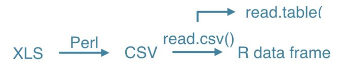

In this respect, the `read.xls()` is an extension of the data import function from the **utils** package to Excel files. This makes it easy to use for people who are familiar with the import functions from the **utils** package and their arguments. On the other hand, the two steps of converting is extremely inefficient. Especially when you have to deal with a huge Excel file; first you have to convert the entire file, then read it.

```r
columns <- c("country", paste0("year_", 1967:1974))
urban_pop <- read.xls("urbanpop.xls", sheet = 2,
         skip = 50, header = FALSE, stringsAsFactors = TRUE,
         col.names = columns)
head(urban_pop)
```

```
##              country  year_1967  year_1968  year_1969  year_1970  year_1971
## 1             Cyprus  231929.74  237831.38  243983.34  250164.52  261213.21
## 2     Czech Republic 6204409.91 6266304.50 6326368.97 6348794.89 6437055.17
## 3            Denmark 3777552.62 3826785.08 3874313.99 3930042.97 3981360.12
## 4           Djibouti   77788.04   84694.35   92045.77   99845.22  107799.69
## 5           Dominica   27550.36   29527.32   31475.62   33328.25   34761.52
## 6 Dominican Republic 1535485.43 1625455.76 1718315.40 1814060.00 1915590.38
##    year_1972  year_1973  year_1974
## 1  272407.99  283774.90  295379.83
## 2 6572632.32 6718465.53 6873458.18
## 3 4028247.92 4076867.28 4120201.43
## 4  116098.23  125391.58  136606.25
## 5   36049.99   37260.05   38501.47
## 6 2020157.01 2127714.45 2238203.87
```

After reading Excel data, we can try to clean and merge it.

```r
path <- "urbanpop.xls"
urban_sheet1 <- read.xls(path, sheet = 1)
urban_sheet2 <- read.xls(path, sheet = 2)
urban_sheet3 <- read.xls(path, sheet = 3)
```

Combine sheets with `cbind()`. Make sure the first column of `urban_sheet2` and `urban_sheet3` are removed to avoid duplicating columns.

```r
urban <- cbind(urban_sheet1,
               urban_sheet2[-1],
               urban_sheet3[-1])
```

Remove all rows with `NA`:

```r
urban_clean <- na.omit(urban)
```

Print out a summary of `urban_clean`:

```r
summary(urban_clean)
```

```
##    country              X1960               X1961               X1962
##  Length:197         Min.   :     3378   Min.   :     3433   Min.   :     3481
##  Class :character   1st Qu.:    87735   1st Qu.:    92905   1st Qu.:    98331
##  Mode  :character   Median :   599714   Median :   630788   Median :   659464
##                     Mean   :  5012388   Mean   :  5282488   Mean   :  5440972
##                     3rd Qu.:  3130085   3rd Qu.:  3155370   3rd Qu.:  3250211
##                     Max.   :126469700   Max.   :129268133   Max.   :131974143
##      X1963               X1964               X1965
##  Min.   :     3532   Min.   :     3586   Min.   :     3644
##  1st Qu.:   104988   1st Qu.:   112084   1st Qu.:   119322
##  Median :   704989   Median :   740609   Median :   774957
##  Mean   :  5612312   Mean   :  5786961   Mean   :  5964970
##  3rd Qu.:  3416490   3rd Qu.:  3585464   3rd Qu.:  3666724
##  Max.   :134599886   Max.   :137205240   Max.   :139663053
##      X1966               X1967               X1968
##  Min.   :     3706   Min.   :     3771   Min.   :     3835
##  1st Qu.:   128565   1st Qu.:   138024   1st Qu.:   147846
##  Median :   809768   Median :   838449   Median :   890270
##  Mean   :  6126413   Mean   :  6288771   Mean   :  6451367
##  3rd Qu.:  3871757   3rd Qu.:  4019906   3rd Qu.:  4158186
##  Max.   :141962708   Max.   :144201722   Max.   :146340364
##      X1969               X1970               X1971
##  Min.   :     3893   Min.   :     3941   Min.   :     4017
##  1st Qu.:   158252   1st Qu.:   171063   1st Qu.:   181483
##  Median :   929450   Median :   976471   Median :  1008630
##  Mean   :  6624909   Mean   :  6799110   Mean   :  6980895
##  3rd Qu.:  4300669   3rd Qu.:  4440047   3rd Qu.:  4595966
##  Max.   :148475901   Max.   :150922373   Max.   :152863831
##      X1972               X1973               X1974
##  Min.   :     4084   Min.   :     4146   Min.   :     4206
##  1st Qu.:   189492   1st Qu.:   197792   1st Qu.:   205410
##  Median :  1048738   Median :  1097293   Median :  1159402
##  Mean   :  7165338   Mean   :  7349454   Mean   :  7540446
##  3rd Qu.:  4766545   3rd Qu.:  4838297   3rd Qu.:  4906384
##  Max.   :154530473   Max.   :156034106   Max.   :157488074
##      X1975               X1976               X1977
##  Min.   :     4267   Min.   :     4334   Min.   :     4402
##  1st Qu.:   211746   1st Qu.:   216991   1st Qu.:   222209
##  Median :  1223146   Median :  1249829   Median :  1311276
##  Mean   :  7731973   Mean   :  7936401   Mean   :  8145945
```

[output cut: 71 more lines]

```
##  Max.   :554367818   Max.   :575050081   Max.   :595731464
##      X2008               X2009               X2010
##  Min.   :     5172   Min.   :     5189   Min.   :     5206
##  1st Qu.:   658017   1st Qu.:   671085   1st Qu.:   684302
##  Median :  3589395   Median :  3652338   Median :  3676309
##  Mean   : 17164898   Mean   : 17533997   Mean   : 17904811
##  3rd Qu.: 10210317   3rd Qu.: 10518289   3rd Qu.: 10618596
##  Max.   :616552722   Max.   :637533976   Max.   :658557734
##      X2011
##  Min.   :     5233
##  1st Qu.:   698009
##  Median :  3664664
##  Mean   : 18276297
##  3rd Qu.: 10731193
##  Max.   :678796403
```

### 2.3 XLConnect

**XLConnect** is one of the most comprehensive packages for working with Excel files through R. written and maintained by Martin Studer. The package is written and maintained by Martin Studer. **XLConnect** works as a bridge between Excel and R. You can do practically any action you could do within Excel inside R. **XLConnect** can work with both *xls* and *xlsx* files, and has easy-to-use functions. To get this all working so smoothly, **XLConnect** depends on *Java*. By installing **XLConnect**, it also installs the dependencies **XLConnectJars** package, which contains Java files and class definition that **XLConnect** depends on it. The **rJava** package will also be installed, providing a low-level R to Java interface that XLConnect uses.

```r
library(XLConnect)
```

First step is loading a workbook into R with `loadWorkbook()`.

```r
book <- loadWorkbook("cities.xlsx")
str(book)
```

```
## Formal class 'workbook' [package "XLConnect"] with 2 slots
##   ..@ filename: chr "cities.xlsx"
##   ..@ jobj    :Formal class 'jobjRef' [package "rJava"] with 2 slots
##   .. .. ..@ jobj  :<externalptr>
##   .. .. ..@ jclass: chr "com/miraisolutions/xlconnect/integration/r/RWorkbookWrapper"
```

This results in a so-called *workbook* object, which is the actual “bridge” between R and Excel. After bulding a workbook object in R, you can use it to get information on the Excel it links to. Use `getSheets()` to get the names of the sheets:

```r
getSheets(book)
```

```
## [1] "year_1990" "year_2000"
```

This works exactly like the `excel_sheets` function from the **readxl** package. The result is a character vector containing the two sheet names. Apart from sheet information, you can also read the actual data from the sheets, like `read_excel()` from **readxl** and `read.xls()` from **gdata**.

```r
readWorksheet(book, sheet = "year_2000")
```

```
##     Capital Population
## 1  New York   17800000
## 2    Berlin    3382169
## 3    Madrid    2938723
## 4 Stockholm    1942362
```

With `readWorksheet()` you can easily specify from which row and which column to start reading information. For example, you want to get the population information for Berlin and Madrid.

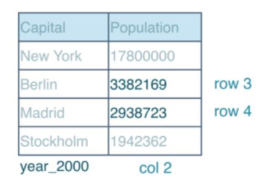

```r
readWorksheet(book, sheet = "year_2000",
              startRow = 3,
              endRow = 4,
              startCol = 2,
              header = FALSE) # because the first row is skipped.
```

```
##      Col1
## 1 3382169
## 2 2938723
```

This package is an easy tool to modify the content of your workbook comfortably through R. For example, if want to add fresh population data from 2010, that is stored in a data frame, `pop_2010`.

```r
pop_2010 <- data.frame(Capital = c("New York", "Berlin", "Madrid", "Stockholm"), Population = c(8191900, 3460725, 3273000, 1372565))
pop_2010
```

```
##     Capital Population
## 1  New York    8191900
## 2    Berlin    3460725
## 3    Madrid    3273000
## 4 Stockholm    1372565
```

To create a sheet with the data of `pop_2010` into the current workbook, first we create a new empty sheet:

[figure not shown]

```r
createSheet(book, name = "year_2010")
```

Next we write the data from `pop_2010` to this new sheet by specifying the name of the new sheet or the number of the sheet:

```r
writeWorksheet(book, pop_2010, sheet = "year_2010") # or sheet = 3
```

Finally you have to explicitly save the entire workbook to a file for the changes to take effect. It is recommended to save it with a new file to avoid overwriting the original file.

```r
saveWorkbook(book, file = "cities2.xlsx")
```

The `renameSheet()` allows you to rename all the sheets. The first argument is the workbook, then pass the old name and the new name:

```r
renameSheet(book, "year_1990", "Y1990")
renameSheet(book, "year_2000", "Y2000")
renameSheet(book, "year_2010", "Y2010")
```

Save the result again to a new file:

```r
saveWorkbook(book, file = "cities3.xlsx")
```

Another job in Excel is to remove the sheets. For example, to remove the third sheet, use `removeSheet()` with the workbook and the sheet name or sheet number as arguments:

```r
removeSheet(book, sheet = "Y2010")
saveWorkbook(book, file = "cities4.xlsx")
```

These are pretty basic operations that can be easily done in Excel, but the cool thing is you can program all of these tasks in R in a reproducible way.

Build a connection to the *urbanpop.xlsx* file in R:

```r
my_book <- loadWorkbook("urbanpop.xlsx")
```

Check again the class of `my_book`:

```r
class(my_book)
```

```
## [1] "workbook"
## attr(,"package")
## [1] "XLConnect"
```

List the sheets in `my_book`:

```r
sheets <- getSheets(my_book)
```

Have an overview about *urbanpop.xlsx* without having to open up the Excel file:

```r
all <- lapply(sheets, readWorksheet, object = my_book)
str(all)
```

```
## List of 3
##  $ :'data.frame':    209 obs. of  8 variables:
##   ..$ country: chr [1:209] "Afghanistan" "Albania" "Algeria" "American Samoa" ...
##   ..$ X1960  : num [1:209] 769308 494443 3293999 NA NA ...
##   ..$ X1961  : num [1:209] 814923 511803 3515148 13660 8724 ...
##   ..$ X1962  : num [1:209] 858522 529439 3739963 14166 9700 ...
##   ..$ X1963  : num [1:209] 903914 547377 3973289 14759 10748 ...
##   ..$ X1964  : num [1:209] 951226 565572 4220987 15396 11866 ...
##   ..$ X1965  : num [1:209] 1000582 583983 4488176 16045 13053 ...
##   ..$ X1966  : num [1:209] 1058743 602512 4649105 16693 14217 ...
##  $ :'data.frame':    209 obs. of  9 variables:
##   ..$ country: chr [1:209] "Afghanistan" "Albania" "Algeria" "American Samoa" ...
##   ..$ X1967  : num [1:209] 1119067 621180 4826104 17349 15440 ...
##   ..$ X1968  : num [1:209] 1182159 639964 5017299 17996 16727 ...
##   ..$ X1969  : num [1:209] 1248901 658853 5219332 18619 18088 ...
##   ..$ X1970  : num [1:209] 1319849 677839 5429743 19206 19529 ...
##   ..$ X1971  : num [1:209] 1409001 698932 5619042 19752 20929 ...
##   ..$ X1972  : num [1:209] 1502402 720207 5815734 20263 22406 ...
##   ..$ X1973  : num [1:209] 1598835 741681 6020647 20742 23937 ...
##   ..$ X1974  : num [1:209] 1696445 763385 6235114 21194 25482 ...
##  $ :'data.frame':    209 obs. of  38 variables:
##   ..$ country: chr [1:209] "Afghanistan" "Albania" "Algeria" "American Samoa" ...
##   ..$ X1975  : num [1:209] 1793266 785350 6460138 21632 27019 ...
##   ..$ X1976  : num [1:209] 1905033 807990 6774099 22047 28366 ...
##   ..$ X1977  : num [1:209] 2021308 830959 7102902 22452 29677 ...
##   ..$ X1978  : num [1:209] 2142248 854262 7447728 22899 31037 ...
##   ..$ X1979  : num [1:209] 2268015 877898 7810073 23457 32572 ...
##   ..$ X1980  : num [1:209] 2398775 901884 8190772 24177 34366 ...
##   ..$ X1981  : num [1:209] 2493265 927224 8637724 25173 36356 ...
##   ..$ X1982  : num [1:209] 2590846 952447 9105820 26342 38618 ...
##   ..$ X1983  : num [1:209] 2691612 978476 9591900 27655 40983 ...
##   ..$ X1984  : num [1:209] 2795656 1006613 10091289 29062 43207 ...
##   ..$ X1985  : num [1:209] 2903078 1037541 10600112 30524 45119 ...
##   ..$ X1986  : num [1:209] 3006983 1072365 11101757 32014 46254 ...
##   ..$ X1987  : num [1:209] 3113957 1109954 11609104 33548 47019 ...
##   ..$ X1988  : num [1:209] 3224082 1146633 12122941 35095 47669 ...
##   ..$ X1989  : num [1:209] 3337444 1177286 12645263 36618 48577 ...
##   ..$ X1990  : num [1:209] 3454129 1198293 13177079 38088 49982 ...
##   ..$ X1991  : num [1:209] 3617842 1215445 13708813 39600 51972 ...
##   ..$ X1992  : num [1:209] 3788685 1222544 14248297 41049 54469 ...
##   ..$ X1993  : num [1:209] 3966956 1222812 14789176 42443 57079 ...
##   ..$ X1994  : num [1:209] 4152960 1221364 15322651 43798 59243 ...
##   ..$ X1995  : num [1:209] 4347018 1222234 15842442 45129 60598 ...
##   ..$ X1996  : num [1:209] 4531285 1228760 16395553 46343 60927 ...
##   ..$ X1997  : num [1:209] 4722603 1238090 16935451 47527 60462 ...
##   ..$ X1998  : num [1:209] 4921227 1250366 17469200 48705 59685 ...
##   ..$ X1999  : num [1:209] 5127421 1265195 18007937 49906 59281 ...
##   ..$ X2000  : num [1:209] 5341456 1282223 18560597 51151 59719 ...
##   ..$ X2001  : num [1:209] 5564492 1315690 19198872 52341 61062 ...
##   ..$ X2002  : num [1:209] 5795940 1352278 19854835 53583 63212 ...
##   ..$ X2003  : num [1:209] 6036100 1391143 20529356 54864 65802 ...
##   ..$ X2004  : num [1:209] 6285281 1430918 21222198 56166 68301 ...
##   ..$ X2005  : num [1:209] 6543804 1470488 21932978 57474 70329 ...
##   ..$ X2006  : num [1:209] 6812538 1512255 22625052 58679 71726 ...
##   ..$ X2007  : num [1:209] 7091245 1553491 23335543 59894 72684 ...
##   ..$ X2008  : num [1:209] 7380272 1594351 24061749 61118 73335 ...
##   ..$ X2009  : num [1:209] 7679982 1635262 24799591 62357 73897 ...
##   ..$ X2010  : num [1:209] 7990746 1676545 25545622 63616 74525 ...
##   ..$ X2011  : num [1:209] 8316976 1716842 26216968 64817 75207 ...
```

Suppose we’re only interested in urban population data of the years 1968, 1969 and 1970. The data for these years is in the columns 3, 4, and 5 of the second sheet.

```r
urbanpop_sel <- readWorksheet(my_book, sheet = 2,
                              startCol = 3,
                              endCol =5)
```

`urbanpop_sel` no longer contains information about the countries now. Import first column from second sheet in `my_book`:

```r
countries <- readWorksheet(my_book,
                           sheet = 2, startCol = 1, endCol = 1)
```

Joining `urbanpop_sel` and `countries` together using `cbind()`:

```r
selection <- cbind(countries, urbanpop_sel)
```

Where **readxl** and **gdata** are only able to import Excel data, **XLConnect**’s approach of providing an actual interface to an Excel file makes it able to edit your Excel files from inside R.

```r
createSheet(my_book, name = "data_summary")
getSheets(my_book)
```

```
## [1] "1960-1966"    "1967-1974"    "1975-2011"    "data_summary"
```

```r
sheets <- getSheets(my_book)[1:3]
dims <- sapply(sheets, function(x) dim(readWorksheet(my_book, sheet = x)), USE.NAMES = FALSE)
summ <- data.frame(sheets = sheets,
                   nrows = dims[1, ],
                   ncols = dims[2, ])
```

Use `writeWorksheet()` to populate the “data_summary” sheet with the `summ` data frame:

```r
writeWorksheet(my_book, summ, sheet = "data_summary")
```

Call `saveWorkbook()` to store the adapted Excel workbook as a new file:

```r
saveWorkbook(my_book, file = "summary.xlsx")
```

“data_summary” is not an ideal name. As the summary of these Excel sheets is always data-related, you simply want to name the sheet “summary”.

```r
renameSheet(my_book, "data_summary", "summary")
```

Print out sheets of `my_book`:

```r
getSheets(my_book)
```

```
## [1] "1960-1966" "1967-1974" "1975-2011" "summary"
```

Finally, make sure to actually save the `my_book` object to a new Excel file:

```r
saveWorkbook(my_book, file = "renamed.xlsx")
```

Remove the fourth sheet:

```r
removeSheet(my_book, sheet = 4)
```

Save the resulting workbook to a file “clean.xlsx”:

```r
saveWorkbook(my_book , file = "clean.xlsx")
```